# Practical Machine Learning Course Project

# Introduction

Using devices such as Jawbone Up, Nike FuelBand, and Fitbit it is now possible to collect a large amount of data about personal activity relatively inexpensively. These type of devices are part of the quantified self movement – a group of enthusiasts who take measurements about themselves regularly to improve their health, to find patterns in their behavior, or because they are tech geeks. One thing that people regularly do is quantify how much of a particular activity they do, but they rarely quantify how well they do it.

In this report, we will be to use data from accelerometers on the belt, forearm, arm, and dumbell of 6 participants. The 5 possible methods are -

A exactly according to the specification B throwing the elbows to the front C lifting the dumbbell only halfway D lowering the dumbbell only halfway E throwing the hips to the front

# Data Preprocessing

## Loading Required Libraries

```r
library(caret)
library(rattle)
```

## Download Data

```r
trainUrl <-"https://d396qusza40orc.cloudfront.net/predmachlearn/pml-training.csv"
testUrl <- "https://d396qusza40orc.cloudfront.net/predmachlearn/pml-testing.csv"
trainFile <- "./pml-training.csv"
testFile  <- "./pml-testing.csv"

if (!file.exists(trainFile)) {
  download.file(trainUrl, destfile=trainFile)
}
if (!file.exists(testFile)) {
  download.file(testUrl, destfile=testFile)
}
```

## Read the Data

After downloading the data from the data source, we can read the two csv files into two data frames.

```r
training<-read.csv("pml-training.csv")
testing<-read.csv("pml-testing.csv")
str(training)
```

```
## 'data.frame':    19622 obs. of  160 variables:
##  $ X                       : int  1 2 3 4 5 6 7 8 9 10 ...
##  $ user_name               : chr  "carlitos" "carlitos" "carlitos" "carlitos" ...
##  $ raw_timestamp_part_1    : int  1323084231 1323084231 1323084231 1323084232 1323084232 1323084232 1323084232 1323084232 1323084232 1323084232 ...
##  $ raw_timestamp_part_2    : int  788290 808298 820366 120339 196328 304277 368296 440390 484323 484434 ...
##  $ cvtd_timestamp          : chr  "05/12/2011 11:23" "05/12/2011 11:23" "05/12/2011 11:23" "05/12/2011 11:23" ...
##  $ new_window              : chr  "no" "no" "no" "no" ...
##  $ num_window              : int  11 11 11 12 12 12 12 12 12 12 ...
##  $ roll_belt               : num  1.41 1.41 1.42 1.48 1.48 1.45 1.42 1.42 1.43 1.45 ...
##  $ pitch_belt              : num  8.07 8.07 8.07 8.05 8.07 8.06 8.09 8.13 8.16 8.17 ...
##  $ yaw_belt                : num  -94.4 -94.4 -94.4 -94.4 -94.4 -94.4 -94.4 -94.4 -94.4 -94.4 ...
##  $ total_accel_belt        : int  3 3 3 3 3 3 3 3 3 3 ...
##  $ kurtosis_roll_belt      : chr  "" "" "" "" ...
##  $ kurtosis_picth_belt     : chr  "" "" "" "" ...
##  $ kurtosis_yaw_belt       : chr  "" "" "" "" ...
```

[output cut: 86 more lines]

```r
dim(training)
```

```
## [1] 19622   160
```

The training data set is made of 19622 observations on 160 columns. We can notice that many columns have NA values or blank values on almost every observation. So we will remove them, because they will not produce any information. The first seven columns give information about the people who did the test, and also timestamps. We will not take them in our model.

## Clean the data

```r
# Here we get the indexes of the columns having at least 80% of NA or blank values on the training dataset
training_clean <- training[,-c(1:7)]
indColToRemove <- which(colSums(is.na(training_clean)|training_clean=="")>0.8*dim(training_clean)[1])
training_clean <- training_clean[,-indColToRemove]
dim(training_clean)
```

```
## [1] 19622    53
```

```r
# Cleaning the test data as well
testing_clean <- testing[,-c(1:7)]
testing_clean <- testing_clean[,-indColToRemove]
```

With the cleaning process above, the number of variables for the analysis has been reduced to 53.

## Slice the data

Then, we can split the cleaned training set into a pure training data set (70%) and a validation data set (30%). We will use the validation data set to conduct cross validation in future steps.

```r
set.seed(1) # For reproducible purpose
inTrain <- createDataPartition(training_clean$classe, p=0.70, list=F)
train_Data <- training_clean[inTrain, ]
valid_Data <- training_clean[-inTrain, ]
```

# Data Modeling

## Remove zero covariates

Let’s see if there are any variable that have little variance so that we can remove them.

```r
nzv<-nearZeroVar(train_Data,saveMetrics = TRUE)
nzv
```

```
##                      freqRatio percentUnique zeroVar   nzv
## roll_belt             1.189597    8.07308728   FALSE FALSE
## pitch_belt            1.044776   12.27342214   FALSE FALSE
## yaw_belt              1.064426   13.03050157   FALSE FALSE
## total_accel_belt      1.073721    0.21110868   FALSE FALSE
## gyros_belt_x          1.040248    0.88811240   FALSE FALSE
## gyros_belt_y          1.154327    0.48045425   FALSE FALSE
## gyros_belt_z          1.054183    1.17929679   FALSE FALSE
## accel_belt_x          1.017889    1.14289874   FALSE FALSE
## accel_belt_y          1.137476    0.99002693   FALSE FALSE
## accel_belt_z          1.093596    2.09652763   FALSE FALSE
## magnet_belt_x         1.065385    2.16204411   FALSE FALSE
## magnet_belt_y         1.119826    2.07468880   FALSE FALSE
## magnet_belt_z         1.021807    3.12295261   FALSE FALSE
## roll_arm             50.978723   17.53658004   FALSE FALSE
## pitch_arm            77.322581   20.28827255   FALSE FALSE
## yaw_arm              31.526316   19.19633108   FALSE FALSE
## total_accel_arm       1.009449    0.48045425   FALSE FALSE
## gyros_arm_x           1.013736    4.57159496   FALSE FALSE
## gyros_arm_y           1.452316    2.68617602   FALSE FALSE
## gyros_arm_z           1.187500    1.73254714   FALSE FALSE
## accel_arm_x           1.073770    5.58346073   FALSE FALSE
## accel_arm_y           1.267123    3.85819320   FALSE FALSE
## accel_arm_z           1.107143    5.53978307   FALSE FALSE
## magnet_arm_x          1.016129    9.56540729   FALSE FALSE
## magnet_arm_y          1.078125    6.21678678   FALSE FALSE
## magnet_arm_z          1.040541    9.14318993   FALSE FALSE
## roll_dumbbell         1.087912   86.53272185   FALSE FALSE
## pitch_dumbbell        2.323232   84.10133217   FALSE FALSE
## yaw_dumbbell          1.112360   85.92123462   FALSE FALSE
## total_accel_dumbbell  1.095388    0.31302322   FALSE FALSE
## gyros_dumbbell_x      1.037825    1.72526753   FALSE FALSE
## gyros_dumbbell_y      1.255474    1.93637621   FALSE FALSE
## gyros_dumbbell_z      1.138686    1.44136274   FALSE FALSE
## accel_dumbbell_x      1.034043    2.99919924   FALSE FALSE
## accel_dumbbell_y      1.046512    3.26126520   FALSE FALSE
## accel_dumbbell_z      1.186747    2.91912353   FALSE FALSE
## magnet_dumbbell_x     1.159292    7.74550484   FALSE FALSE
## magnet_dumbbell_y     1.272727    5.99111888   FALSE FALSE
## magnet_dumbbell_z     1.043478    4.81910170   FALSE FALSE
## roll_forearm         11.635193   13.65654801   FALSE FALSE
## pitch_forearm        63.023256   19.03617966   FALSE FALSE
## yaw_forearm          14.648649   12.73931717   FALSE FALSE
## total_accel_forearm   1.105802    0.48045425   FALSE FALSE
## gyros_forearm_x       1.008043    2.06012958   FALSE FALSE
## gyros_forearm_y       1.045802    5.18308219   FALSE FALSE
## gyros_forearm_z       1.076471    2.08196841   FALSE FALSE
## accel_forearm_x       1.193548    5.64897721   FALSE FALSE
## accel_forearm_y       1.080000    7.09033996   FALSE FALSE
## accel_forearm_z       1.043478    4.01106501   FALSE FALSE
## magnet_forearm_x      1.033898   10.54815462   FALSE FALSE
## magnet_forearm_y      1.101695   13.27800830   FALSE FALSE
## magnet_forearm_z      1.023810   11.66921453   FALSE FALSE
## classe                1.469526    0.03639805   FALSE FALSE
```

Since there are no variables with zero variance, we can continue using the same dataset.

Three methods will be applied to model the regressions (in the Train dataset) and the best one (with higher accuracy when applied to the Test dataset) will be used for the quiz predictions. The methods are: Random Forests, Decision Tree and Generalized Boosted Model, as described below. In order to limit the effects of overfitting, and improve the efficicency of the models, we will use the *cross-validation technique. We will use 5 folds (usually, 5 or 10 can be used, but 10 folds gives higher run times with no significant increase of the accuracy).

## Trees

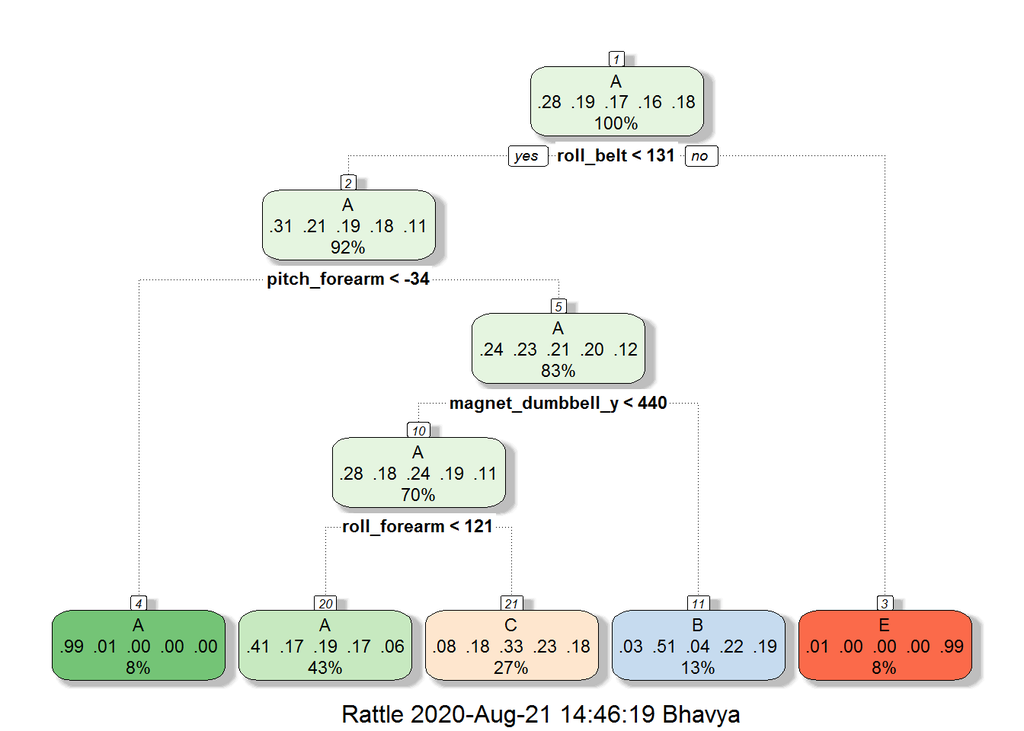

```r
trControl <- trainControl(method="cv", number=5)
set.seed(2)
mod_tree<-train(classe~.,data=train_Data,trControl=trControl,method="rpart")
fancyRpartPlot(mod_tree$finalModel)
```

```r
pred_tree<-predict(mod_tree,valid_Data)
acc_tree<-confusionMatrix(pred_tree,as.factor(valid_Data$classe))$overall[1]
```

## Random Forests

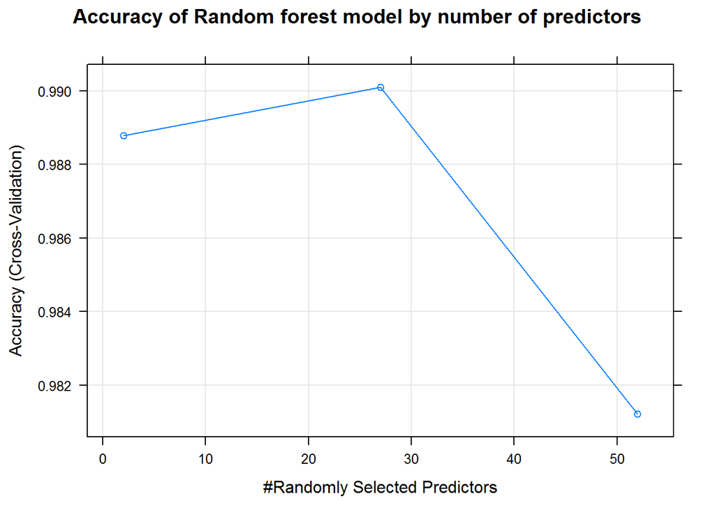

```r
set.seed(3)
mod_RF<-train(classe~.,data=train_Data,trControl=trControl,method="rf", ntree=100)
plot(mod_RF,main="Accuracy of Random forest model by number of predictors")
```

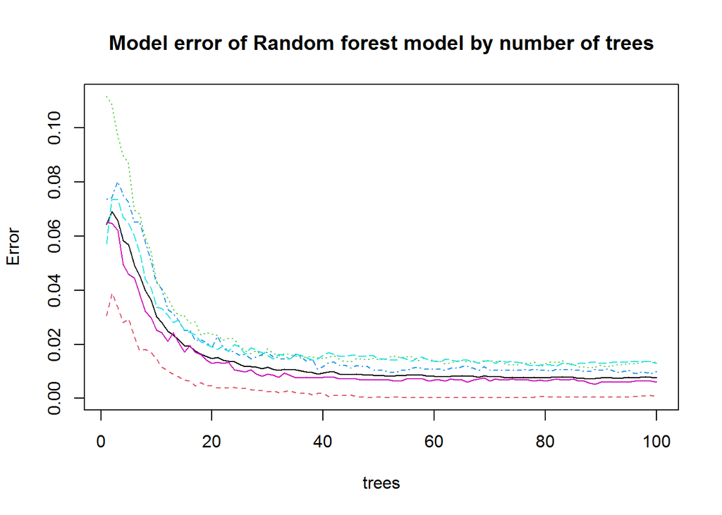

```r
pred_RF<-predict(mod_RF,valid_Data)
acc_RF<-confusionMatrix(pred_RF,as.factor(valid_Data$classe))$overall[1]
plot(mod_RF$finalModel,main="Model error of Random forest model by number of trees")
```

## Boosting

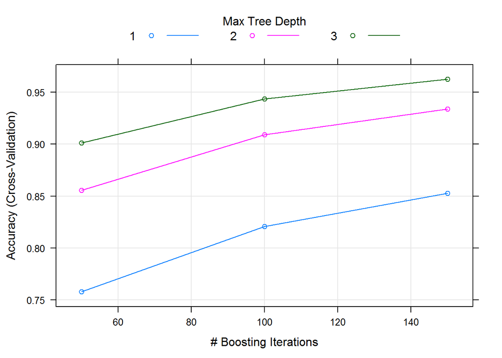

```r
set.seed(4)
mod_gbm<-train(classe~.,data=train_Data,trControl=trControl,method="gbm", verbose=FALSE)
plot(mod_gbm)
```

```r
pred_gbm<-predict(mod_gbm,valid_Data)
acc_gbm<-confusionMatrix(pred_gbm,as.factor(valid_Data$classe))$overall[1]
```

## Analysing accuracy

```r
AccuracyResults <- data.frame(
  Model = c('CART', 'GBM', 'RF'),
  Accuracy = rbind(acc_tree, acc_gbm, acc_RF)
)
print(AccuracyResults)
```

```
##          Model  Accuracy
## acc_tree  CART 0.4875106
## acc_gbm    GBM 0.9571793
## acc_RF      RF 0.9923534
```

# Conclusion

Since the random forest model has the highest accuracy, we will then use it to predict the values of classe for the test data set.

```r
FinalTestPred <- predict(mod_RF,newdata=testing_clean)
FinalTestPred
```

```
##  [1] B A B A A E D B A A B C B A E E A B B B
## Levels: A B C D E
```

## References

The data used a courtesy of:

Velloso, E.; Bulling, A.; Gellersen, H.; Ugulino, W.; Fuks, H. [Qualitative Activity Recognition of Weight Lifting Exercises](http://groupware.les.inf.puc-rio.br/work.jsf?p1=11201). Proceedings of 4th International Conference in Cooperation with SIGCHI (Augmented Human ’13). Stuttgart, Germany: ACM SIGCHI, 2013.